# Lasso & sparse portfolios

This is the companion notebook for the course on the **LASSO** and its application for **sparse portfolios** and **penalised predictive regressions**.

$\rightarrow$ **ABOUT THE NOTEBOOK**:

- the code chunks are **sequential**. They must be executed in the correct order.
- text between **stars** appears in bold in html format.

# 1 Preliminaries

First, we load the packages and import the data. The steps are the same as before. Notably, we immediately add the future/forward returns (**f_return**) in addition to the past/current returns (**p_return**).

```r
if(!require(glmnet)){install.packages("glmnet", "tictoc", "scales", "ggrepel", "ggcorrplot")}
library(glmnet)                                     # This is THE package for penalised regressions
library(tidyverse)                                  # ... the usual core packages
library(ggrepel)                                    # Package for ggplot annotations
library(scales)                                     # Package for scales in ggplot
library(tictoc)                                     # Package for computation time
library(ggcorrplot)                                 # Visualizing the correlation matrices
load("data_new.RData")                              # Loading the data
data <- data %>% arrange(date, symbol)              # Just making sure all is in order
symbol <- unique(data$symbol)                       # Set of assets
data <- data  %>%
    select(-scope_1) %>%                            # Remove ESG: too many missing points
    group_by(symbol) %>%                            # Group asset by asset
    mutate(p_return = close / lag(close) - 1) %>%   # Adding past returns
    mutate(f_return = lead(p_return)) %>%           # Adding forward returns: could to better
    ungroup()                                       # Ungroup
```

First, we want to handle missing points because they will be a pain in models. Hence, we resort to cross-sectional imputation (median).

```r
impute_ <- function(v){
  v[is.na(v)] <- median(v, na.rm = T)
  v
}
data <- data |>
  group_by(date) |>
  mutate(across(where(is.numeric), impute_)) |>
  ungroup() |>
  na.omit()
```

Let’s have a look at correlations.

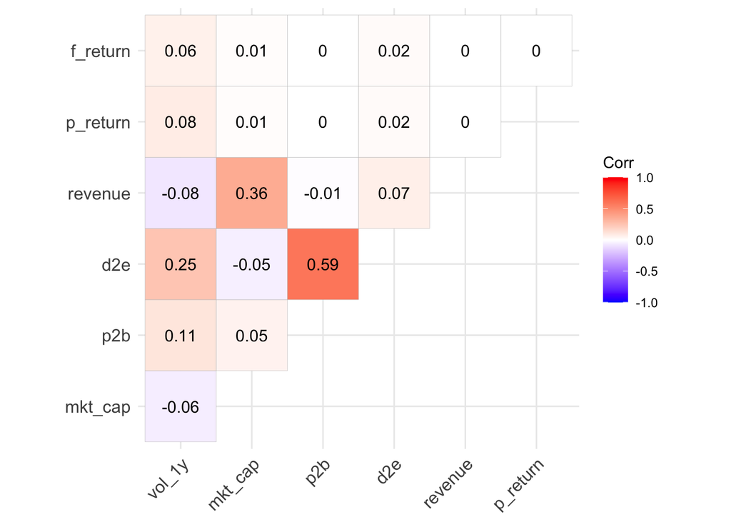

```r
data[,4:10] %>% cor() %>% round(3) %>%              # Correlation matrix
  ggcorrplot(type = "upper", lab = TRUE)
```

There seems to be a positive link between **Market cap** and the **Revenue** Let’s have a closer look (**note**: not much to say about the forward return…).  
We build a pivot-table of averages over all firms and plot the result.

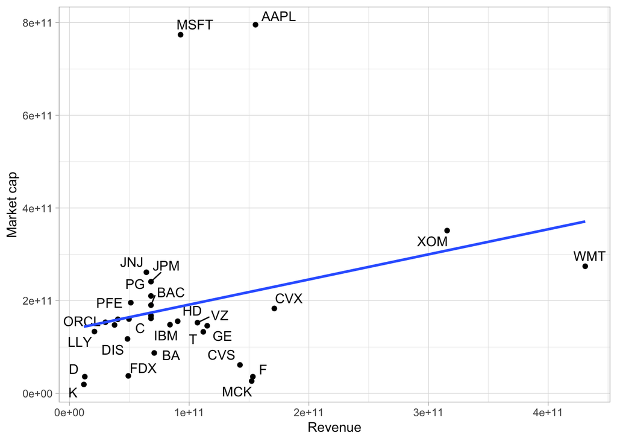

```r
data %>%
  group_by(symbol) %>%                                # Building a pivot table
  summarise(avg_mkt = mean(mkt_cap),
            avg_rev = mean(revenue, na.rm = T)) %>%
  ggplot(aes(x = avg_rev, y = avg_mkt)) + geom_point() +
  geom_text_repel(aes(label = symbol)) + theme_light() +
  ylab("Market cap") + xlab("Revenue") +
  geom_smooth(method = "lm", se = FALSE)
```

The coefficients are available at:

```r
data %>%
  group_by(symbol) %>%                                # Building a pivot table
  summarise(avg_mkt = mean(mkt_cap, na.rm = T),
            avg_rev = mean(revenue, na.rm = T)) %>%
  lm(avg_mkt ~ avg_rev, data = .)                  # Compute the regression
```

```
##
## Call:
## lm(formula = avg_mkt ~ avg_rev, data = .)
##
## Coefficients:
## (Intercept)      avg_rev
##   1.372e+11    5.420e-01
```

Indeed, even at the aggregate level, the positive relationship seems to hold! The blue line shows the best *linear* fit for the data.

# 2 About the OLS assumptions

Below, we explicit the expectation of the residuals of a linear model (based on quadratic Data Generating Process), conditional on the values of X. Clearly this is an issue for inference.

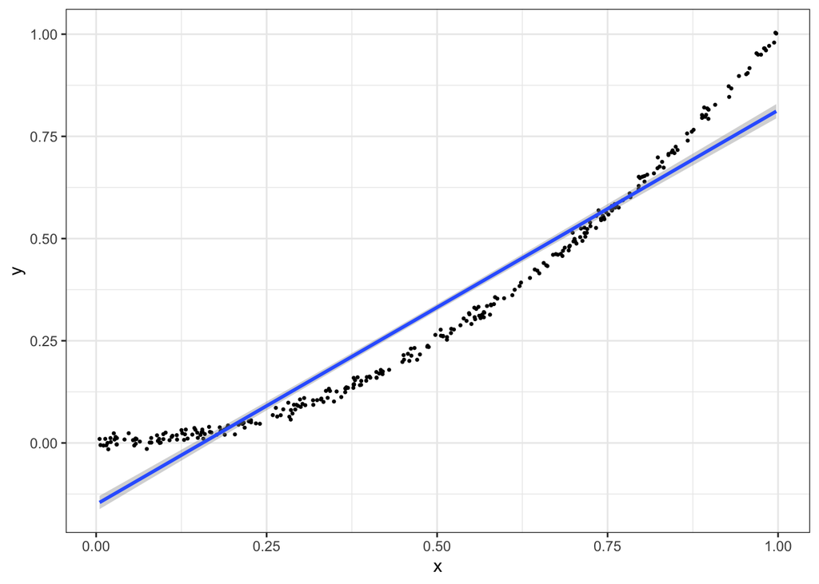

```r
n <- 300
x <- runif(n)
y <- x^2 + rnorm(n) / 100
data.frame(x = x, y = y) %>%
    ggplot(aes(x = x, y = y)) + geom_point(size = 0.5) + geom_smooth(method = "lm") +
    theme_bw()
```

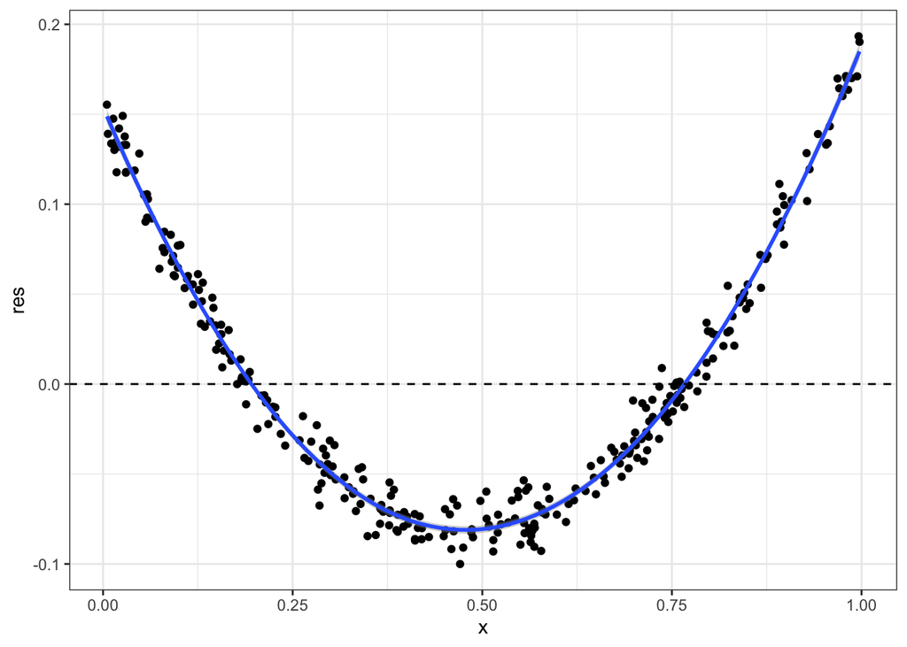

```r
data.frame(res = lm(y ~ x)$residuals, x = x) %>%
    ggplot(aes(x = x, y = res)) + geom_point() + theme_bw() +
    geom_smooth() +
    geom_hline(yintercept = 0, linetype = 2)
```

Simply put, this means that $\mathbb{E}[\epsilon | \textbf{X}]$ is not zero. Therefore, in the expectation of the mean of the estimator, the term with the errors does not collapse.

# 3 Simple predictions

Next, we look at the impact of the **regularisation intensities** on the outcome of **penalised regressions**.

## 3.1 First, a linear model

We choose to work with a simple example. We investigate if the cross-section of characteristics can help understand the cross-section of future returns (directly, without resorting to the definition of asset-pricing factors). To do so, we normalise the firm characteristics using the scale() function. The scaling is performed each point in time. Finally, we estimate the following regression:

$$R_{t+1}=a + b^{cap}cap_t+\dots
+b^{P2B}P2B_t+\epsilon_t.$$

Note that characteristics are lagged compared to returns: the scheme is clearly **predictive**.  
**Note**: below, we scale returns, which may not be a great idea… In fact, it’s a pooled panel model.

```r
data %>%
    group_by(date) %>%                           # Grouping to normalise on a date basis
    mutate_if(is.numeric, scale) %>%             # Scaled chars
    ungroup() %>%                                # Ungroup: global variable
    select(-date, -symbol, -close) %>%             # Remove irrelevant columns
    lm(f_return ~ ., data = .) %>%               # Perform the regression
    summary() %>%                                # Get the summary
    "$"(coef) %>%                                # Keeping only the coefs & stats
    round(3) %>%                                 # Round up to 3 digits
    data.frame()                                 # Convert to dataframe
```

```
##             Estimate Std..Error t.value Pr...t..
## (Intercept)    0.000      0.010   0.000    1.000
## vol_1y         0.025      0.011   2.282    0.022
## mkt_cap       -0.013      0.012  -1.050    0.294
## p2b            0.005      0.011   0.456    0.649
## d2e           -0.019      0.012  -1.609    0.108
## revenue       -0.005      0.012  -0.410    0.682
## p_return      -0.009      0.011  -0.808    0.419
```

## 3.2 First step with the LASSO

We start with the general definition of penalised regression proposed by the **elasticnet** (Zou & Hastie (2005)). It can be characterised by its Lagrange form:

$$\underset{\mathbf{\beta}}{\text{min}} \,
\left\{(\mathbf{Y}- \mathbf{X} \mathbf{\beta})'(\mathbf{Y}-
\mathbf{X} \mathbf{\beta})+\lambda \alpha || \mathbf{\beta}
||_1+\lambda (1-\alpha)||\mathbf{\beta}||_2^2\right\},$$
where $\lambda>0$, $\alpha\in[0,1]$. When $\alpha=1$, we recover the so-called **LASSO** (Tibshirani (1996)) and when $\alpha=0$, we get the classical ridge regression, which is a very smooth regularisation of the usual regression. In our case, the predicted value $\mathbf{Y}$ will be the future return $\mathbf{R}_{t+1}$ and $\mathbf{X}$ the other scaled variables.

We start with the case of the LASSO. When running, **glmnet**() performs a series of LASSO estimations with many possible values for the penalisation constant (**lambda** in the function’s arguments).

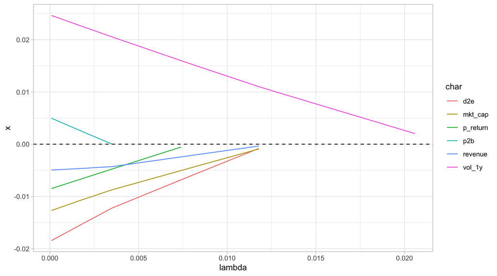

```r
data_lasso <-  data %>%
    group_by(date) %>%                                      # Grouping to normalise, date-by-date
    mutate_if(is.numeric, scale) %>%                         # Scaled chars
    ungroup() |>                                            # Ungroup: global variable
    na.omit()
y <- data_lasso$f_return                                    # Dependent variable: ORIGINAL returns!
x <- data_lasso %>%                                         # Independent variables
    select(-symbol, -date, -close, -f_return) %>%           # Removing irrelevant columns
    as.matrix()                                             # Transform in base matrix
fit <- glmnet(x,y, alpha = 1)                               # Performing the LASSO: 1 = Lasso, 0 = Ridge
# Below, we format the results
var_names <- colnames(data)[4:10]                           # Names of independent variables
res <- summary(fit$beta)                                    # Summary of the series of LASSO regressions
lambda <- fit$lambda                                        # Values of the penalisation constant
res$lambda <- lambda[res$j]                                 # Putting the labels where they belong
res$char <- var_names[res$i] %>% as.factor()                # Adding names of variables to the output
res %>% ggplot(aes(x = lambda, y = x, color = char)) +      # Plot!
  geom_line() + theme_light() + geom_hline(yintercept = 0, linetype = 2)
```

The value of coefficients (*y*-axis) is a function of the penalisation intensity (**lambda**). As the latter increases, the magnitude of coefficient decreases. **vol_1y** dominates and the convergence to zero of the other variables is somewhat rapid.

Overall, the curves are angular and in straight lines.

## 3.3 Ridge regression

We then switch to **ridge regressions**. The penalisation in this case is a multiple of the $L^2$ norm of the coefficients.

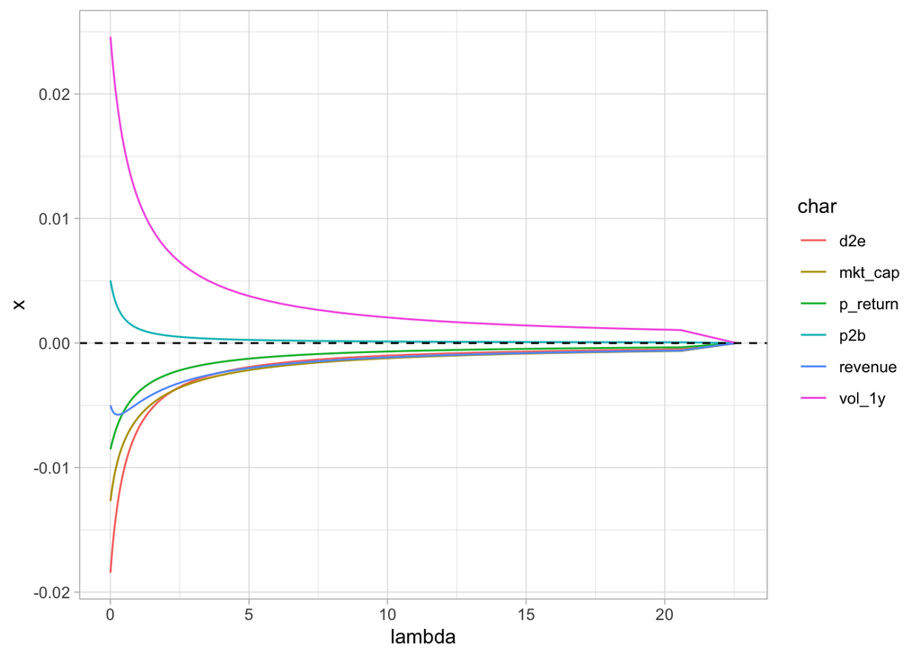

```r
fit <- glmnet(x,y, alpha = 0)                          # Performing ridge regression: 1 = Lasso, 0 = Ridge
res <- summary(fit$beta)                               # Summary of the series of ridge regressions
lambda <- fit$lambda                                   # Values of the penalisation constant
res$lambda <- lambda[res$j]                            # Putting the labels where they belong
res$char <- var_names[res$i] %>% as.factor()           # Adding the names of variables to the output
res %>% ggplot(aes(x = lambda, y = x, color = char)) + # Plot!
  geom_line() + theme_light() + geom_hline(yintercept = 0, linetype = 2)
```

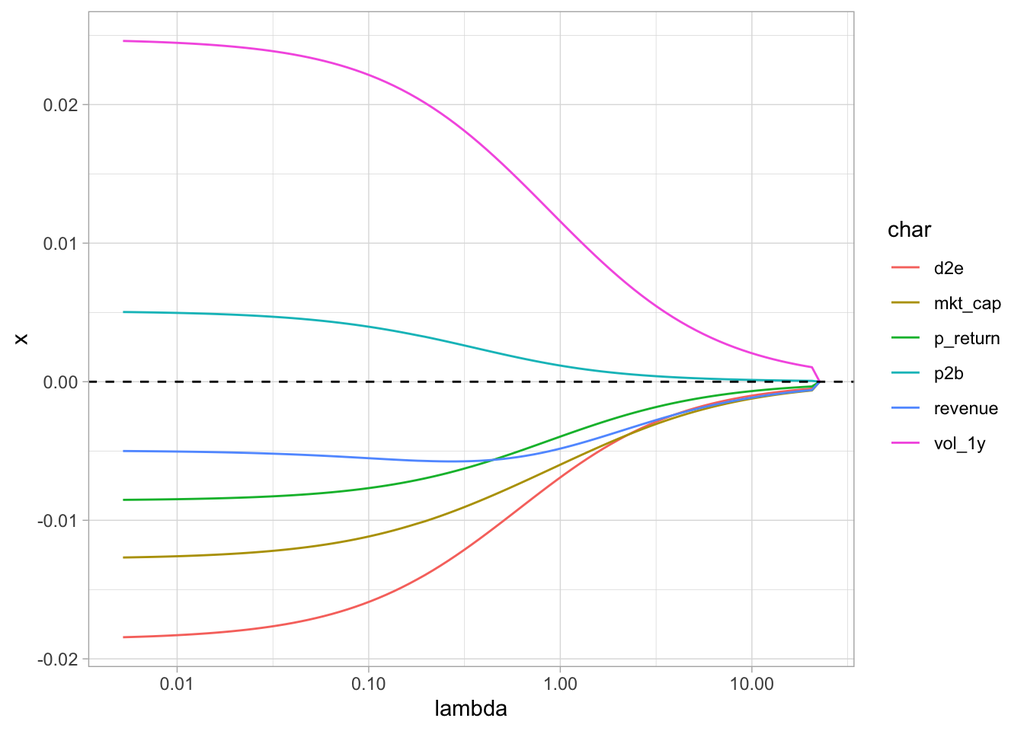

```r
res %>% ggplot(aes(x = lambda, y = x, color = char)) + # Logscale plot
  geom_line() + scale_x_log10() + theme_light() +
    geom_hline(yintercept = 0, linetype = 2)
```

On the above graph, we used a logarithmic scale to discern the relative convergence speed of each coefficient (the bulk of the first graph is unclear). In contrast to the **LASSO**, the convergence is **very smooth**.

## 3.4 Elasticnet: the best of two worlds?

Because the LASSO (harsh convergence) and the ridge regression (smooth convergence) have very different outcomes, there was a natural gap between the two that was filled by the **elasticnet** (Zou and Hastie 2005). The penalisation in this case is a **linear convex combination** of both types of norms: $a||\beta||_1+(1-a)||\beta||_2^2$.

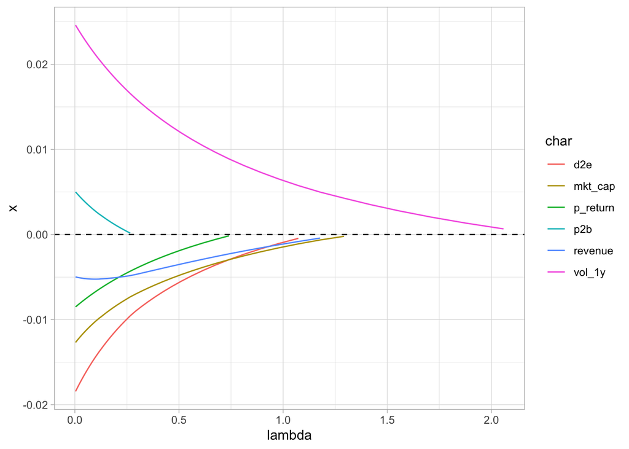

```r
fit <- glmnet(x,y, alpha = 0.01)                       # The elasticnet: 1 = Lasso, 0 = Ridge
res <- summary(fit$beta)                               # Summary of elasticnet regressions
lambda <- fit$lambda                                   # Values of the penalisation constant
res$lambda <- lambda[res$j]                            # Putting the labels where they belong
res$char <- var_names[res$i] %>% as.factor()           # Adding the names of variables to the output
res %>% ggplot(aes(x = lambda, y = x, color = char)) + # Plot
  geom_line() + theme_light() + geom_hline(yintercept = 0, linetype = 2)
```

# 4 Sparse hedging portfolios

We now turn to the application of the **LASSO** to sparse portfolios (see Goto & Xu 2015 for the full implementation and Stevens 1998 for the original idea).

## 4.1 Setup

We first initialise the variables. Sparse portfolios are based on **returns** only; we thus build a dedicated variable (in matrix/rectangular format).

```r
sep_date <- as.Date("2010-01-01")           # This date separates in-sample vs out-of-sample
t_oos <- data$date[data$date>sep_date] %>%  # Out-of-sample dates (i.e., testing set)
    unique() %>%                            # Remove duplicates
    as.Date(origin = "1970-01-01")          # Transform in date format
returns <- data %>%                         # Computing returns, in matrix format, in 2 steps:
    select(date, symbol, p_return) %>%        # 1. Keep returns along with dates & firm names
    pivot_wider(names_from = symbol,          # 2. Put in matrix shape
                values_from = p_return) |>
  na.omit()
# Below, we initialise the variables used in the backtesting loop
portf_weights <- matrix(0, nrow = length(t_oos), ncol = length(symbol))
portf_returns <- vector(mode = "numeric", length = length(t_oos))
returns                                     # A look at the returns
```

```
## # A tibble: 296 × 31
##    date          AAPL      BA     BAC       C    CSCO      CVS      CVX        D
##    <date>       <dbl>   <dbl>   <dbl>   <dbl>   <dbl>    <dbl>    <dbl>    <dbl>
##  1 2000-12-31 -0.0985 -0.0443  0.149   0.0251 -0.201   0.0538   0.0313   0.117
##  2 2001-01-31  0.454  -0.114   0.173   0.0961 -0.0212 -0.0123  -0.0137  -0.0776
##  3 2001-02-28 -0.156   0.0632 -0.0719 -0.121  -0.367   0.0304   0.0286   0.0608
##  4 2001-03-31  0.209  -0.104   0.0961 -0.0854 -0.332  -0.0411   0.0250  -0.0166
##  5 2001-04-30  0.155   0.109   0.0228  0.0927  0.0738  0.00786  0.0998   0.0624
##  6 2001-05-31 -0.217   0.0176  0.0580  0.0427  0.134  -0.0687  -0.00528 -0.0320
##  7 2001-06-30  0.165  -0.116   0.0132  0.0310 -0.0550 -0.297   -0.0578  -0.0931
##  8 2001-07-31 -0.192   0.0527  0.0598 -0.0498  0.0560 -0.0671   0.00983  0.00599
##  9 2001-08-31 -0.0128 -0.125  -0.0333 -0.0888 -0.150   0.00278 -0.00700  0.0407
## 10 2001-09-30 -0.164  -0.346  -0.0504 -0.115  -0.254  -0.0806  -0.0661  -0.0572
## # ℹ 286 more rows
## # ℹ 22 more variables: DIS <dbl>, F <dbl>, FDX <dbl>, GE <dbl>, HD <dbl>,
## #   IBM <dbl>, INTC <dbl>, JNJ <dbl>, JPM <dbl>, K <dbl>, LLY <dbl>, MCK <dbl>,
## #   MRK <dbl>, MSFT <dbl>, ORCL <dbl>, PFE <dbl>, PG <dbl>, T <dbl>, VZ <dbl>,
## #   WFC <dbl>, WMT <dbl>, XOM <dbl>
```

The core of the engine is the weighting function. Inside this function, the user will have two degrees of freedom: $alpha$, which is the intensity between LASSO and ridge in the **glmnet**() function and $\lambda$ which indicates the strength of the constraint. We recall that the approach is based on $n$ regressions of the type:
$$\underset{\beta_{i|}}{\text{argmin}}\,
\left\{\sum_{t=1}^T\left( r_{i,t}-a_i-\sum_{n\neq
i}^N\beta_{i|n}r_{n,t}\right)^2+\lambda \alpha || \beta||_1+\lambda
(1-\alpha)||\beta||_2^2\right\},$$
where each asset’s returns are regressed against those of all other assets. The purpose is to **hedge the risk** of the asset thanks to position in the other assets. Due to **estimation errors**, the unconstrained regression performs poorly and is often very leveraged. The penalisation is intended to solve these two problems.

```r
weights_lasso <- function(returns, alpha, lambda){  # The parameters are defined here
    w <- 0                                          # Initiate weights
    for(i in 1:ncol(returns)){                      # Loop on the assets
        y <- returns[,i]                            # Dependent variable
        x <- returns[,-i]                           # Independent variable
        fit <- glmnet(x,y, family = "gaussian", alpha = alpha, lambda = lambda)
        err <- y-predict(fit, x)                    # Prediction errors
        w[i] <- (1-sum(fit$beta))/var(err)          # Output: weight of asset i
    }
    return(w / sum(w))                              # Normalisation of weights
}
```

## 4.2 First results

Finally, we move to the main loop, which has the same structure as those seen previously.

```r
for(t in 1:length(t_oos)){
    temp_data <- returns %>% filter(date < t_oos[t]) %>%    # Extracting past data: expand. window
        select(-date) %>%                                   # Take out the date
        as.matrix()                                         # Into matrix: glmnet requires matrices
    portf_weights[t,] <- weights_lasso(temp_data, 0.01, 0.1)# Hard-coded parameters! User specified!
    realised_returns <- returns %>%                         # Realised returns:
        filter(date == t_oos[t]) %>%                        # Filtered by date
        select(-date)                                       # With date removed
    portf_returns[t] <- sum(portf_weights[t,] * realised_returns) # Portfolio returns
}
```

We then recall the **perf_met**() function, to which we added the turnover.

```r
perf_met <- function(portf_returns, weights, asset_returns){
    avg_ret <- 12*mean(portf_returns, na.rm = T)                  # Arithmetic mean
    vol <- sqrt(12)*sd(portf_returns, na.rm = T)                  # Volatility
    Sharpe_ratio <- avg_ret / vol                                 # Sharpe ratio
    VaR_5 <- 12*quantile(portf_returns, 0.05)                     # Value-at-risk
    turn <- 0                                                     # Initialisation of turnover
    for(t in 2:dim(weights)[1]){
        realised_returns <- asset_returns %>% filter(date == t_oos[t]) %>% select(-date)
        prior_weights <- weights[t-1,] * (1 + realised_returns)
        turn <- turn + apply(abs(weights[t,] - prior_weights/sum(prior_weights)),1,sum)
    }
    turn <- turn/(length(t_oos)-1)                                # Average over time
    met <- data.frame(avg_ret, vol, Sharpe_ratio, VaR_5, turn)    # Aggregation of all of this
    rownames(met) <- "metrics"
    return(met)
}

asset_returns <- filter(returns, date>sep_date)                   # Keep out-of-sample returns
perf_met(portf_returns, portf_weights, asset_returns)             # Compute perf metrics
```

```
##            avg_ret      vol Sharpe_ratio      VaR_5      turn
## metrics 0.07945562 0.108708    0.7309086 -0.6185031 0.0480401
```

Let’s have a look at the weights.

```r
portf_weights <- bind_cols(t_oos, as_tibble(portf_weights))
colnames(portf_weights) <- c("date", symbol)
```

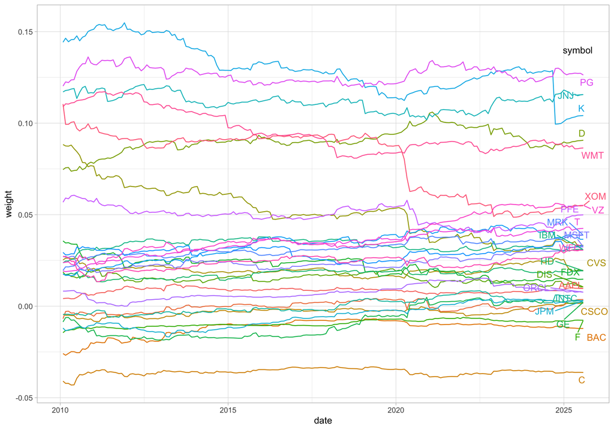

```r
portf_weights %>%
  pivot_longer(-date, names_to = "stock", values_to = "weight") %>%
  ggplot(aes(x = date, y = weight, color = stock)) +
  geom_line() + theme_light() +
  geom_text_repel(aes(label = stock), hjust = -0.2,
            data = portf_weights %>%
               pivot_longer(-date, names_to = "stock", values_to = "weight") %>%
               filter(date == max(date))) +
  annotate("text", x = as.Date("2025-06-01"), y = 0.14, label = "symbol") +
  theme(legend.position = "none")
```

## 4.3 Comparing strategies

The purpose of the sparse portfolios is to **reduce the volatility**. Let’s see how it compares to the other classical schemes. First, we build the weighting function. It’s just a concatenation of functions we saw previously.

```r
weights_multi <- function(returns, j, alpha, lambda){
    N <- ncol(returns)
    if(j == 1){                     # j = 1 => EW
        return(rep(1/N,N))
    }
    if(j == 2){                     # j = 2 => Minimum Variance
        sigma <- cov(returns)
        w <- solve(sigma) %*% rep(1,N)
        return(w / sum(w))
    }
    if(j == 3){                     # j = 3 => Maximum Sharpe Ratio
        m <- apply(returns, 2, mean)
        sigma <- cov(returns)
        w <- solve(sigma) %*% m
        return(w / sum(w))
    }
    if(j == 4){                     # j = 4 => Penalised / elasticnet
        w <- weights_lasso(returns, alpha, lambda)
    }
}
```

**Note** that this does take some space in the script. A helpful shortcut is to create a separate file where you store the functions only. Below, we proceed to initialisation of variables and jump directly the main loop. Given that we compute the weights and returns for 4 portfolios, it takes a bit longer.

```r
Tt <- length(t_oos)                                             # Nb of dates, avoid T = TRUE
nb_port <- 4                                                    # Nb of portfolios
portf_weights <- array(0, dim = c(Tt, nb_port, length(symbol)))   # Store weights
portf_returns <- matrix(0, nrow = Tt, ncol = nb_port)           # Store returns

for(t in 1:length(t_oos)){
    temp_data <- returns %>%
        filter(date < t_oos[t]) %>%
        select(-date) %>%
        as.matrix()
    realised_returns <- returns %>%
        filter(date == t_oos[t]) %>%
        select(-date)
    for(j in 1:nb_port){
        portf_weights[t,j,] <- weights_multi(temp_data, j, 0.1, 0.01)  # Hard-coded parameters!
        portf_returns[t,j] <- sum(portf_weights[t,j,] * realised_returns)
    }
}
```

Finally, we compute the corresponding **performance metrics**. Because of the complex nature of **perf_met()**, we use a small loop.

```r
port_names <- c("EW", "MinVar", "MSR", "LASSO") # Portfolio names
met <- c()                                  # Initialise metrics
for(i in 1:nb_port){
    met <- rbind(met, perf_met(portf_returns[,i], portf_weights[,i,], asset_returns)) # Ugly!
}
met %>% data.frame(row.names = port_names)  # Display results
```

```
##           avg_ret       vol Sharpe_ratio      VaR_5       turn
## EW     0.10802828 0.1358762    0.7950492 -0.6436119 0.04290263
## MinVar 0.09220198 0.1168969    0.7887461 -0.5204438 0.11061728
## MSR    0.19520083 0.2256549    0.8650414 -1.0233461 0.47398052
## LASSO  0.08159396 0.1114444    0.7321498 -0.5649633 0.07405896
```

The parameters of the **LASSO** portfolio play a decisive role in the performance of the strategy: they should be chosen carefully after sensitivity tests show how they impact the results. The $\lambda$ will dictate the amount of constraint on the coefficients. A strict constraint will build more stable and sparse portfolios, but the weights will be further from those of the MV portfolio. As usual, it’s all a matter of **tradeoff**.

# 5 Pure LASSO predictions

Another use of the **LASSO** would simply be to use it as **predictive tool**. In this case, the explanatory variables would be, e.g., the firms’ characteristics. Below, we show how to implement the predictive regression approach. More precisely, it is a **pooled panel** estimation.

```r
weights_pure_lasso <- function(past_data, current_data, alpha, lambda){
    y <- past_data$f_return                                 # Dependent variable
    x <- past_data %>%                                      # Independent variables
        select(-symbol, -date, -close, -f_return) %>%         # Remove irrelevant columns
        as.matrix()                                         # Format to matrix shape
    fit <- glmnet(x,y, alpha = alpha, lambda = lambda)      # Performing the glmnet regression
    newx <- current_data %>%                                # Preparing the new data
        select(-symbol, -date, -close, -f_return) %>%         # Remove irrelevant columns
        as.matrix()                                         # Format to matrix shape
    pred <- predict(fit, newx = newx)                       # Launching the prediction
    w <- pred > median(pred)                                # Invests only if positive prediction
    return(w/sum(w))                                        # Then, equal weights
}
```

Below, we launch the main loop. Because of the forward return we must go one step backward in the out-of-sample dates. Indeed, before, we took data up to $t-1$ to decide the allocation at time $t-1$ and apply the return observed at time $t$. Since we resort to the forward return, we must go back to time $t-2$. The decision is made with the values at time $t-1$:

- past up to t-2: training data
- t-1: data used for the current prediction
- the return from **t-1** to **t** is the future return applied to the strategy

To ‘simplify’ the architecture, we simply define a new vector of out-of-sample dates.

```r
t_oos2 <- data$date[data$date>sep_date-20] %>%          # New dates, we take one more (prev. month)!::
    unique() %>%                                        # Remove duplicates
    as.Date(origin = "1970-01-01")                      # Transform in date format
portf_weights <- matrix(0, nrow = length(t_oos), ncol = length(symbol))   # Initialisation
portf_returns <- c()                                                    # Initialisation

for(t in 2:length(t_oos2)){                                             # Current time is t-1
    past_data <- data_lasso %>% filter(date < t_oos2[t-1])              # Past data: expanding window
    current_data <- data_lasso %>% filter(date == t_oos2[t-1])          # Extracting current data
    portf_weights[t-1,] <- weights_pure_lasso(past_data,current_data, 0.1, 0.01)
    # Hard-coded parameters above! User specified!
    realised_returns <- returns %>%                     # Realised returns
        filter(date ==  t_oos2[t]) %>%                  # Note: starts at t = 2, equal to t_oos[1]
        select(-date)                                   # Take out date column
    portf_returns[t-1] <- sum(portf_weights[t-1,] * realised_returns)
    # Note: t-1, like for the portfolios !!!
}
asset_returns <- filter(returns, date %in% t_oos) # And not t_oos2!
perf_met(portf_returns, portf_weights, asset_returns)
```

```
##          avg_ret       vol Sharpe_ratio      VaR_5      turn
## metrics 0.112166 0.1588541    0.7060945 -0.7772499 0.3963837
```

The performance is reasonably good compared to our previous results. The **average return** is quite high, but the risk has also increased (the VaR, notably). The turnover is nonetheless much too high.

# 6 Exercises

## 6.1 Simple tests

Try different values for alpha and lambda in the sparse portfolios and see if it is possible to reduce the out-of-sample volatility.

Try to change sep_date to before 2008.

## 6.2 LASSO tuning

Create a **backtesting function** and the corresponding backtesting loop that tests several parameter values for:  
- the LASSO-based sparse portfolios  
- the predictive LASSO strategies

# 7 BONUS: sensitivity analysis of LASSO - Min Var portfolios

Is it possible to improve the volatility of the penalized minimum variance portfolio?  
Given the computation time of only one backtest, this will take some time.

```r
# Below, we create a function that depends on the two parameters
lasso_sensi <- function(alpha, lambda, t_oos, symbol, returns){
    portf_weights <- matrix(0, nrow = length(t_oos), ncol = length(symbol))
    portf_returns <- c()
    for(t in 1:length(t_oos)){
        temp_data <- returns %>% filter(date < t_oos[t]) %>%    # Extracting past data: expnd. wndw
            select(-date) %>%                                   # Take out the date
            as.matrix()                                         # Into matrix
        portf_weights[t,] <- weights_lasso(temp_data, alpha, lambda)
        realised_returns <- returns %>%                         # Realised returns:
            filter(date ==  t_oos[t]) %>%                       # Filtered by date
            select(-date)                                       # With date removed
        portf_returns[t] <- sum(portf_weights[t,] * realised_returns) # Portfolio returns
    }
    return(sd(portf_returns))
}

alpha <- c(0.001, 0.01, 0.1)             # alpha values
lambda <- c(0.001, 0.01, 0.1, 1)         # lambda values
pars <- expand.grid(alpha, lambda)       # Exploring all combinations!
alpha <- pars[,1]
lambda <- pars[,2]
tic()                                    # Launch the clock
vols <- pmap(list(alpha, lambda),        # Parameters for the grid search
             lasso_sensi,                # Function on which to apply pmap
             t_oos = t_oos,              # The other inputs below
             symbol = symbol,
             returns = returns)
toc()                                    # Stop the clock!
```

```
## 57.05 sec elapsed
```

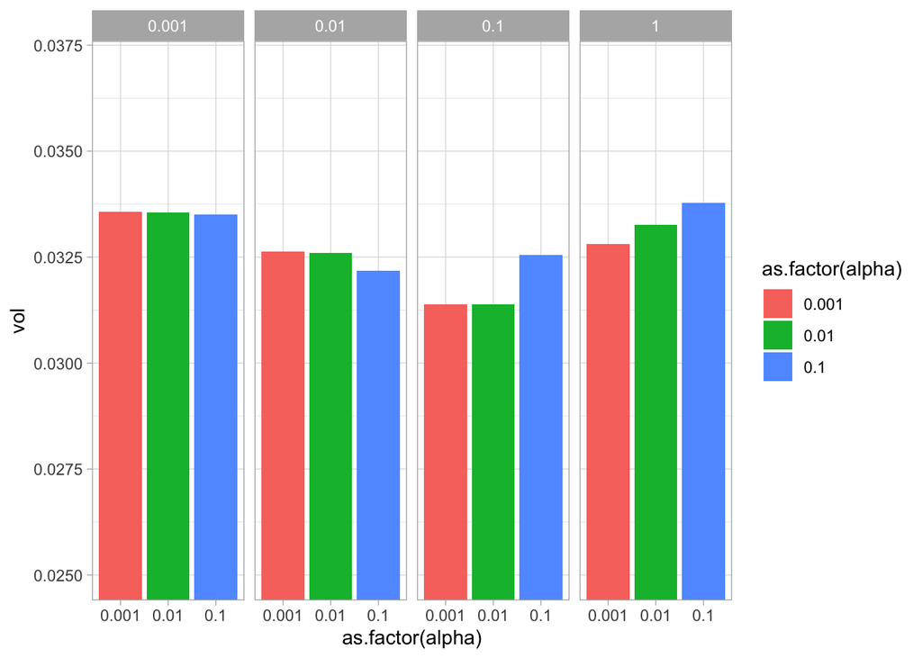

```r
vols <- vols %>%
    unlist() %>%
    cbind(as.matrix(pars)) %>%
    data.frame()
colnames(vols) <- c("vol", "alpha", "lambda")
vols %>% ggplot(aes(x = as.factor(alpha), y = vol, fill = as.factor(alpha))) +
  geom_col() + facet_grid(~lambda) + theme_light() +
  scale_y_continuous(limits = c(0.025, 0.037), oob = rescale_none)
```

The original parameters were a rather good choice.